# Risk Factor Analysis

## Outcome Variable

**Outcome Variable:** ever_stunted

## Predictor Variables

**Intervention Variable:** nhh

**Adjustment Set:**

- arm
- W_mage
- meducyrs
- feducyrs
- W_mhtcm
- W_mwtkg
- W_mbmi
- W_nrooms
- impfloor
- impsan
- safeh20
- delta_W_mage
- delta_meducyrs
- delta_feducyrs
- delta_W_mhtcm
- delta_W_mwtkg
- delta_W_mbmi
- delta_W_nrooms
- delta_impfloor
- delta_impsan
- delta_safeh20

## Stratifying Variables

The analysis was stratified on these variable(s):

- agecat
- studyid
- country

## Data Summary

| agecat | studyid | country | nhh | ever_stunted | n_cell | n |
| --- | --- | --- | --- | --- | --- | --- |
| 0-24 months | ki1000108-IRC | INDIA | 3 or less | 0 | 25 | 410 |
| 0-24 months | ki1000108-IRC | INDIA | 3 or less | 1 | 33 | 410 |
| 0-24 months | ki1000108-IRC | INDIA | 4-5 | 0 | 52 | 410 |
| 0-24 months | ki1000108-IRC | INDIA | 4-5 | 1 | 106 | 410 |
| 0-24 months | ki1000108-IRC | INDIA | 6-7 | 0 | 41 | 410 |
| 0-24 months | ki1000108-IRC | INDIA | 6-7 | 1 | 66 | 410 |
| 0-24 months | ki1000108-IRC | INDIA | 8+ | 0 | 29 | 410 |
| 0-24 months | ki1000108-IRC | INDIA | 8+ | 1 | 58 | 410 |
| 0-24 months | ki1000304b-SAS-FoodSuppl | INDIA | 3 or less | 0 | 9 | 418 |
| 0-24 months | ki1000304b-SAS-FoodSuppl | INDIA | 3 or less | 1 | 29 | 418 |
| 0-24 months | ki1000304b-SAS-FoodSuppl | INDIA | 4-5 | 0 | 35 | 418 |
| 0-24 months | ki1000304b-SAS-FoodSuppl | INDIA | 4-5 | 1 | 148 | 418 |
| 0-24 months | ki1000304b-SAS-FoodSuppl | INDIA | 6-7 | 0 | 16 | 418 |
| 0-24 months | ki1000304b-SAS-FoodSuppl | INDIA | 6-7 | 1 | 111 | 418 |
| 0-24 months | ki1000304b-SAS-FoodSuppl | INDIA | 8+ | 0 | 12 | 418 |
| 0-24 months | ki1000304b-SAS-FoodSuppl | INDIA | 8+ | 1 | 58 | 418 |
| 0-24 months | ki1017093-NIH-Birth | BANGLADESH | 3 or less | 0 | 47 | 629 |
| 0-24 months | ki1017093-NIH-Birth | BANGLADESH | 3 or less | 1 | 70 | 629 |
| 0-24 months | ki1017093-NIH-Birth | BANGLADESH | 4-5 | 0 | 77 | 629 |
| 0-24 months | ki1017093-NIH-Birth | BANGLADESH | 4-5 | 1 | 187 | 629 |
| 0-24 months | ki1017093-NIH-Birth | BANGLADESH | 6-7 | 0 | 42 | 629 |
| 0-24 months | ki1017093-NIH-Birth | BANGLADESH | 6-7 | 1 | 100 | 629 |
| 0-24 months | ki1017093-NIH-Birth | BANGLADESH | 8+ | 0 | 45 | 629 |
| 0-24 months | ki1017093-NIH-Birth | BANGLADESH | 8+ | 1 | 61 | 629 |
| 0-24 months | ki1017093b-PROVIDE | BANGLADESH | 3 or less | 0 | 83 | 700 |
| 0-24 months | ki1017093b-PROVIDE | BANGLADESH | 3 or less | 1 | 57 | 700 |
| 0-24 months | ki1017093b-PROVIDE | BANGLADESH | 4-5 | 0 | 179 | 700 |
| 0-24 months | ki1017093b-PROVIDE | BANGLADESH | 4-5 | 1 | 143 | 700 |
| 0-24 months | ki1017093b-PROVIDE | BANGLADESH | 6-7 | 0 | 84 | 700 |
| 0-24 months | ki1017093b-PROVIDE | BANGLADESH | 6-7 | 1 | 67 | 700 |

[output cut: 114 more lines]

The following strata were considered:

- agecat: 0-24 months, studyid: ki1000108-IRC, country: INDIA
- agecat: 0-24 months, studyid: ki1000304b-SAS-FoodSuppl, country: INDIA
- agecat: 0-24 months, studyid: ki1017093-NIH-Birth, country: BANGLADESH
- agecat: 0-24 months, studyid: ki1017093b-PROVIDE, country: BANGLADESH
- agecat: 0-24 months, studyid: ki1017093c-NIH-Crypto, country: BANGLADESH
- agecat: 0-24 months, studyid: ki1148112-LCNI-5, country: MALAWI
- agecat: 0-6 months, studyid: ki1000108-IRC, country: INDIA
- agecat: 0-6 months, studyid: ki1000304b-SAS-FoodSuppl, country: INDIA
- agecat: 0-6 months, studyid: ki1017093-NIH-Birth, country: BANGLADESH
- agecat: 0-6 months, studyid: ki1017093b-PROVIDE, country: BANGLADESH
- agecat: 0-6 months, studyid: ki1017093c-NIH-Crypto, country: BANGLADESH
- agecat: 0-6 months, studyid: ki1148112-LCNI-5, country: MALAWI
- agecat: 6-24 months, studyid: ki1000108-IRC, country: INDIA
- agecat: 6-24 months, studyid: ki1000304b-SAS-FoodSuppl, country: INDIA
- agecat: 6-24 months, studyid: ki1017093-NIH-Birth, country: BANGLADESH
- agecat: 6-24 months, studyid: ki1017093b-PROVIDE, country: BANGLADESH
- agecat: 6-24 months, studyid: ki1017093c-NIH-Crypto, country: BANGLADESH
- agecat: 6-24 months, studyid: ki1148112-LCNI-5, country: MALAWI

### Dropped Strata

Some strata were dropped due to rare outcomes:

- agecat: 0-6 months, studyid: ki1148112-LCNI-5, country: MALAWI

## Methods Detail

We’re interested in the causal parameters $E[Y_a]$ for all values of $a \in \mathcal{A}$. These parameters represent the mean outcome if, possibly contrary to fact, we intervened to set all units to have $A=a$. Under the randomization and positivity assumptions, these are identified by the statistical parameters $\psi_a=E_W[E_{Y|A,W}(Y|A=a,W)]$. In addition, we’re interested in the mean of $Y$, $E[Y]$ under no intervention (the observed mean). We will estimate these parameters by using SuperLearner to fit the relevant likelihood factors – $E_{Y|A,W}(Y|A=a,W)$ and $p(A=a|W)$, and then updating our likelihood fit using a joint TMLE.

For unadjusted analyses ($W=\{\}$), initial likelihoods were estimated using Lrnr_glm to estimate the simple $E(Y|A)$ and Lrnr_mean to estimate $p(A)$. For adjusted analyses, a small library containing Lrnr_glmnet, Lrnr_xgboost, and Lrnr_mean was used.

Having estimated these parameters, we will then use the delta method to estimate relative risks and attributable risks relative to a prespecified baseline level of $A$.

# Results Detail

## Results Plots

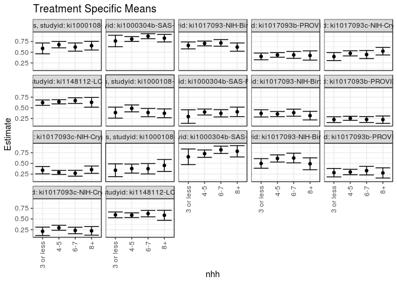

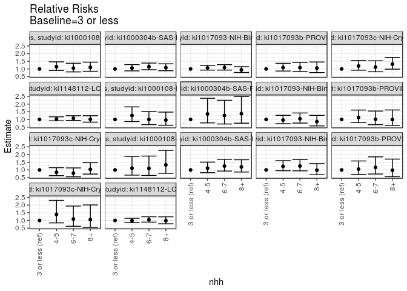

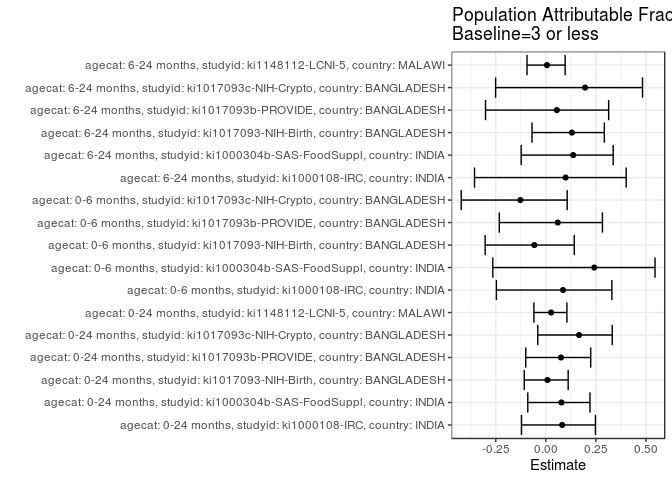

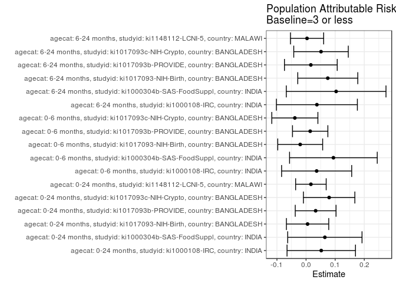

## Results Table

### Parameter: TSM

| agecat | studyid | country | intervention_level | baseline_level | estimate | ci_lower | ci_upper |
| --- | --- | --- | --- | --- | --- | --- | --- |
| 0-24 months | ki1000108-IRC | INDIA | 3 or less | NA | 0.5892445 | 0.4622033 | 0.7162856 |
| 0-24 months | ki1000108-IRC | INDIA | 4-5 | NA | 0.6767103 | 0.6019834 | 0.7514371 |
| 0-24 months | ki1000108-IRC | INDIA | 6-7 | NA | 0.6207187 | 0.5252162 | 0.7162212 |
| 0-24 months | ki1000108-IRC | INDIA | 8+ | NA | 0.6526089 | 0.5517914 | 0.7534264 |
| 0-24 months | ki1000304b-SAS-FoodSuppl | INDIA | 3 or less | NA | 0.7631579 | 0.6278220 | 0.8984938 |
| 0-24 months | ki1000304b-SAS-FoodSuppl | INDIA | 4-5 | NA | 0.8087432 | 0.7516931 | 0.8657933 |
| 0-24 months | ki1000304b-SAS-FoodSuppl | INDIA | 6-7 | NA | 0.8740157 | 0.8162349 | 0.9317966 |
| 0-24 months | ki1000304b-SAS-FoodSuppl | INDIA | 8+ | NA | 0.8285714 | 0.7401768 | 0.9169660 |
| 0-24 months | ki1017093-NIH-Birth | BANGLADESH | 3 or less | NA | 0.6593196 | 0.5785699 | 0.7400693 |
| 0-24 months | ki1017093-NIH-Birth | BANGLADESH | 4-5 | NA | 0.7050427 | 0.6493056 | 0.7607798 |
| 0-24 months | ki1017093-NIH-Birth | BANGLADESH | 6-7 | NA | 0.7180154 | 0.6406739 | 0.7953569 |
| 0-24 months | ki1017093-NIH-Birth | BANGLADESH | 8+ | NA | 0.6197773 | 0.5231380 | 0.7164166 |
| 0-24 months | ki1017093b-PROVIDE | BANGLADESH | 3 or less | NA | 0.4013464 | 0.3230052 | 0.4796876 |
| 0-24 months | ki1017093b-PROVIDE | BANGLADESH | 4-5 | NA | 0.4362915 | 0.3826256 | 0.4899573 |
| 0-24 months | ki1017093b-PROVIDE | BANGLADESH | 6-7 | NA | 0.4366574 | 0.3556289 | 0.5176860 |
| 0-24 months | ki1017093b-PROVIDE | BANGLADESH | 8+ | NA | 0.4232693 | 0.3151138 | 0.5314249 |
| 0-24 months | ki1017093c-NIH-Crypto | BANGLADESH | 3 or less | NA | 0.3983082 | 0.3057495 | 0.4908669 |
| 0-24 months | ki1017093c-NIH-Crypto | BANGLADESH | 4-5 | NA | 0.4739816 | 0.4136973 | 0.5342659 |
| 0-24 months | ki1017093c-NIH-Crypto | BANGLADESH | 6-7 | NA | 0.4457579 | 0.3507794 | 0.5407364 |
| 0-24 months | ki1017093c-NIH-Crypto | BANGLADESH | 8+ | NA | 0.5236938 | 0.4347920 | 0.6125956 |
| 0-24 months | ki1148112-LCNI-5 | MALAWI | 3 or less | NA | 0.6210168 | 0.5584407 | 0.6835930 |
| 0-24 months | ki1148112-LCNI-5 | MALAWI | 4-5 | NA | 0.6410998 | 0.5911177 | 0.6910818 |
| 0-24 months | ki1148112-LCNI-5 | MALAWI | 6-7 | NA | 0.6688348 | 0.6015163 | 0.7361534 |
| 0-24 months | ki1148112-LCNI-5 | MALAWI | 8+ | NA | 0.6289645 | 0.5156080 | 0.7423210 |
| 0-6 months | ki1000108-IRC | INDIA | 3 or less | NA | 0.3880047 | 0.2589796 | 0.5170298 |
| 0-6 months | ki1000108-IRC | INDIA | 4-5 | NA | 0.4866883 | 0.4061810 | 0.5671956 |
| 0-6 months | ki1000108-IRC | INDIA | 6-7 | NA | 0.3884039 | 0.2919295 | 0.4848784 |
| 0-6 months | ki1000108-IRC | INDIA | 8+ | NA | 0.3722545 | 0.2694413 | 0.4750678 |
| 0-6 months | ki1000304b-SAS-FoodSuppl | INDIA | 3 or less | NA | 0.2954614 | 0.1376692 | 0.4532536 |
| 0-6 months | ki1000304b-SAS-FoodSuppl | INDIA | 4-5 | NA | 0.4015670 | 0.3319756 | 0.4711583 |
| 0-6 months | ki1000304b-SAS-FoodSuppl | INDIA | 6-7 | NA | 0.3713244 | 0.2858073 | 0.4568416 |
| 0-6 months | ki1000304b-SAS-FoodSuppl | INDIA | 8+ | NA | 0.4063240 | 0.2955395 | 0.5171085 |
| 0-6 months | ki1017093-NIH-Birth | BANGLADESH | 3 or less | NA | 0.3698464 | 0.2852962 | 0.4543966 |
| 0-6 months | ki1017093-NIH-Birth | BANGLADESH | 4-5 | NA | 0.3544391 | 0.2948159 | 0.4140623 |
| 0-6 months | ki1017093-NIH-Birth | BANGLADESH | 6-7 | NA | 0.3854804 | 0.3029485 | 0.4680123 |
| 0-6 months | ki1017093-NIH-Birth | BANGLADESH | 8+ | NA | 0.3169594 | 0.2164428 | 0.4174760 |
| 0-6 months | ki1017093b-PROVIDE | BANGLADESH | 3 or less | NA | 0.2243627 | 0.1566860 | 0.2920394 |
| 0-6 months | ki1017093b-PROVIDE | BANGLADESH | 4-5 | NA | 0.2540160 | 0.2064662 | 0.3015658 |
| 0-6 months | ki1017093b-PROVIDE | BANGLADESH | 6-7 | NA | 0.2268429 | 0.1577794 | 0.2959065 |
| 0-6 months | ki1017093b-PROVIDE | BANGLADESH | 8+ | NA | 0.2227963 | 0.1367428 | 0.3088499 |
| 0-6 months | ki1017093c-NIH-Crypto | BANGLADESH | 3 or less | NA | 0.3406107 | 0.2542214 | 0.4270001 |
| 0-6 months | ki1017093c-NIH-Crypto | BANGLADESH | 4-5 | NA | 0.2889677 | 0.2413560 | 0.3365794 |
| 0-6 months | ki1017093c-NIH-Crypto | BANGLADESH | 6-7 | NA | 0.2701999 | 0.2023852 | 0.3380145 |
| 0-6 months | ki1017093c-NIH-Crypto | BANGLADESH | 8+ | NA | 0.3535029 | 0.2677612 | 0.4392447 |
| 6-24 months | ki1000108-IRC | INDIA | 3 or less | NA | 0.3398831 | 0.1904767 | 0.4892895 |
| 6-24 months | ki1000108-IRC | INDIA | 4-5 | NA | 0.3788301 | 0.2733472 | 0.4843129 |
| 6-24 months | ki1000108-IRC | INDIA | 6-7 | NA | 0.3751502 | 0.2537754 | 0.4965250 |
| 6-24 months | ki1000108-IRC | INDIA | 8+ | NA | 0.4524874 | 0.3130155 | 0.5919593 |
| 6-24 months | ki1000304b-SAS-FoodSuppl | INDIA | 3 or less | NA | 0.6538462 | 0.4706024 | 0.8370899 |
| 6-24 months | ki1000304b-SAS-FoodSuppl | INDIA | 4-5 | NA | 0.7281553 | 0.6420565 | 0.8142542 |
| 6-24 months | ki1000304b-SAS-FoodSuppl | INDIA | 6-7 | NA | 0.8181818 | 0.7318558 | 0.9045078 |
| 6-24 months | ki1000304b-SAS-FoodSuppl | INDIA | 8+ | NA | 0.7837838 | 0.6508654 | 0.9167021 |
| 6-24 months | ki1017093-NIH-Birth | BANGLADESH | 3 or less | NA | 0.4993078 | 0.3866194 | 0.6119963 |
| 6-24 months | ki1017093-NIH-Birth | BANGLADESH | 4-5 | NA | 0.6160729 | 0.5323339 | 0.6998119 |
| 6-24 months | ki1017093-NIH-Birth | BANGLADESH | 6-7 | NA | 0.6261856 | 0.5130125 | 0.7393587 |
| 6-24 months | ki1017093-NIH-Birth | BANGLADESH | 8+ | NA | 0.4911603 | 0.3516018 | 0.6307188 |
| 6-24 months | ki1017093b-PROVIDE | BANGLADESH | 3 or less | NA | 0.2833234 | 0.1845312 | 0.3821156 |
| 6-24 months | ki1017093b-PROVIDE | BANGLADESH | 4-5 | NA | 0.2983267 | 0.2346031 | 0.3620504 |
| 6-24 months | ki1017093b-PROVIDE | BANGLADESH | 6-7 | NA | 0.3307275 | 0.2307112 | 0.4307437 |
| 6-24 months | ki1017093b-PROVIDE | BANGLADESH | 8+ | NA | 0.2774020 | 0.1577514 | 0.3970527 |
| 6-24 months | ki1017093c-NIH-Crypto | BANGLADESH | 3 or less | NA | 0.2114359 | 0.1132434 | 0.3096284 |
| 6-24 months | ki1017093c-NIH-Crypto | BANGLADESH | 4-5 | NA | 0.2943513 | 0.2362584 | 0.3524441 |
| 6-24 months | ki1017093c-NIH-Crypto | BANGLADESH | 6-7 | NA | 0.2316064 | 0.1556537 | 0.3075591 |
| 6-24 months | ki1017093c-NIH-Crypto | BANGLADESH | 8+ | NA | 0.2224230 | 0.1221048 | 0.3227411 |
| 6-24 months | ki1148112-LCNI-5 | MALAWI | 3 or less | NA | 0.5966029 | 0.5287557 | 0.6644502 |
| 6-24 months | ki1148112-LCNI-5 | MALAWI | 4-5 | NA | 0.5890116 | 0.5340194 | 0.6440039 |
| 6-24 months | ki1148112-LCNI-5 | MALAWI | 6-7 | NA | 0.6263736 | 0.5509011 | 0.7018461 |
| 6-24 months | ki1148112-LCNI-5 | MALAWI | 8+ | NA | 0.5868303 | 0.4695530 | 0.7041075 |

### Parameter: E(Y)

| agecat | studyid | country | intervention_level | baseline_level | estimate | ci_lower | ci_upper |
| --- | --- | --- | --- | --- | --- | --- | --- |
| 0-24 months | ki1000108-IRC | INDIA | NA | NA | 0.6414634 | 0.5949863 | 0.6879405 |
| 0-24 months | ki1000304b-SAS-FoodSuppl | INDIA | NA | NA | 0.8277512 | 0.7915095 | 0.8639929 |
| 0-24 months | ki1017093-NIH-Birth | BANGLADESH | NA | NA | 0.6645469 | 0.6276196 | 0.7014742 |
| 0-24 months | ki1017093b-PROVIDE | BANGLADESH | NA | NA | 0.4342857 | 0.3975409 | 0.4710305 |
| 0-24 months | ki1017093c-NIH-Crypto | BANGLADESH | NA | NA | 0.4775726 | 0.4419904 | 0.5131548 |
| 0-24 months | ki1148112-LCNI-5 | MALAWI | NA | NA | 0.6376989 | 0.6047193 | 0.6706785 |
| 0-6 months | ki1000108-IRC | INDIA | NA | NA | 0.4243902 | 0.3764905 | 0.4722900 |
| 0-6 months | ki1000304b-SAS-FoodSuppl | INDIA | NA | NA | 0.3894231 | 0.3425088 | 0.4363374 |
| 0-6 months | ki1017093-NIH-Birth | BANGLADESH | NA | NA | 0.3497615 | 0.3124631 | 0.3870600 |
| 0-6 months | ki1017093b-PROVIDE | BANGLADESH | NA | NA | 0.2385714 | 0.2069753 | 0.2701675 |
| 0-6 months | ki1017093c-NIH-Crypto | BANGLADESH | NA | NA | 0.3021108 | 0.2694011 | 0.3348205 |
| 6-24 months | ki1000108-IRC | INDIA | NA | NA | 0.3771186 | 0.3151523 | 0.4390850 |
| 6-24 months | ki1000304b-SAS-FoodSuppl | INDIA | NA | NA | 0.7572016 | 0.7031798 | 0.8112234 |
| 6-24 months | ki1017093-NIH-Birth | BANGLADESH | NA | NA | 0.5739130 | 0.5216565 | 0.6261696 |
| 6-24 months | ki1017093b-PROVIDE | BANGLADESH | NA | NA | 0.2997812 | 0.2577294 | 0.3418330 |
| 6-24 months | ki1017093c-NIH-Crypto | BANGLADESH | NA | NA | 0.2628458 | 0.2244546 | 0.3012371 |
| 6-24 months | ki1148112-LCNI-5 | MALAWI | NA | NA | 0.6000000 | 0.5639396 | 0.6360604 |

### Parameter: RR

| agecat | studyid | country | intervention_level | baseline_level | estimate | ci_lower | ci_upper |
| --- | --- | --- | --- | --- | --- | --- | --- |
| 0-24 months | ki1000108-IRC | INDIA | 3 or less | 3 or less | 1.0000000 | 1.0000000 | 1.000000 |
| 0-24 months | ki1000108-IRC | INDIA | 4-5 | 3 or less | 1.1484372 | 0.9014121 | 1.463158 |
| 0-24 months | ki1000108-IRC | INDIA | 6-7 | 3 or less | 1.0534146 | 0.8083070 | 1.372847 |
| 0-24 months | ki1000108-IRC | INDIA | 8+ | 3 or less | 1.1075351 | 0.8500326 | 1.443043 |
| 0-24 months | ki1000304b-SAS-FoodSuppl | INDIA | 3 or less | 3 or less | 1.0000000 | 1.0000000 | 1.000000 |
| 0-24 months | ki1000304b-SAS-FoodSuppl | INDIA | 4-5 | 3 or less | 1.0597324 | 0.8756092 | 1.282573 |
| 0-24 months | ki1000304b-SAS-FoodSuppl | INDIA | 6-7 | 3 or less | 1.1452620 | 0.9477874 | 1.383881 |
| 0-24 months | ki1000304b-SAS-FoodSuppl | INDIA | 8+ | 3 or less | 1.0857143 | 0.8827484 | 1.335347 |
| 0-24 months | ki1017093-NIH-Birth | BANGLADESH | 3 or less | 3 or less | 1.0000000 | 1.0000000 | 1.000000 |
| 0-24 months | ki1017093-NIH-Birth | BANGLADESH | 4-5 | 3 or less | 1.0693489 | 0.9248696 | 1.236398 |
| 0-24 months | ki1017093-NIH-Birth | BANGLADESH | 6-7 | 3 or less | 1.0890248 | 0.9264950 | 1.280066 |
| 0-24 months | ki1017093-NIH-Birth | BANGLADESH | 8+ | 3 or less | 0.9400256 | 0.7715194 | 1.145335 |
| 0-24 months | ki1017093b-PROVIDE | BANGLADESH | 3 or less | 3 or less | 1.0000000 | 1.0000000 | 1.000000 |
| 0-24 months | ki1017093b-PROVIDE | BANGLADESH | 4-5 | 3 or less | 1.0870697 | 0.8652831 | 1.365704 |
| 0-24 months | ki1017093b-PROVIDE | BANGLADESH | 6-7 | 3 or less | 1.0879815 | 0.8332817 | 1.420532 |
| 0-24 months | ki1017093b-PROVIDE | BANGLADESH | 8+ | 3 or less | 1.0546235 | 0.7657477 | 1.452477 |
| 0-24 months | ki1017093c-NIH-Crypto | BANGLADESH | 3 or less | 3 or less | 1.0000000 | 1.0000000 | 1.000000 |
| 0-24 months | ki1017093c-NIH-Crypto | BANGLADESH | 4-5 | 3 or less | 1.1899871 | 0.9147786 | 1.547991 |
| 0-24 months | ki1017093c-NIH-Crypto | BANGLADESH | 6-7 | 3 or less | 1.1191282 | 0.8180496 | 1.531017 |
| 0-24 months | ki1017093c-NIH-Crypto | BANGLADESH | 8+ | 3 or less | 1.3147954 | 0.9876466 | 1.750309 |
| 0-24 months | ki1148112-LCNI-5 | MALAWI | 3 or less | 3 or less | 1.0000000 | 1.0000000 | 1.000000 |
| 0-24 months | ki1148112-LCNI-5 | MALAWI | 4-5 | 3 or less | 1.0323388 | 0.9102400 | 1.170816 |
| 0-24 months | ki1148112-LCNI-5 | MALAWI | 6-7 | 3 or less | 1.0769995 | 0.9351031 | 1.240428 |
| 0-24 months | ki1148112-LCNI-5 | MALAWI | 8+ | 3 or less | 1.0127979 | 0.8247904 | 1.243661 |
| 0-6 months | ki1000108-IRC | INDIA | 3 or less | 3 or less | 1.0000000 | 1.0000000 | 1.000000 |
| 0-6 months | ki1000108-IRC | INDIA | 4-5 | 3 or less | 1.2543361 | 0.8653782 | 1.818117 |
| 0-6 months | ki1000108-IRC | INDIA | 6-7 | 3 or less | 1.0010289 | 0.6612634 | 1.515370 |
| 0-6 months | ki1000108-IRC | INDIA | 8+ | 3 or less | 0.9594072 | 0.6228591 | 1.477801 |
| 0-6 months | ki1000304b-SAS-FoodSuppl | INDIA | 3 or less | 3 or less | 1.0000000 | 1.0000000 | 1.000000 |
| 0-6 months | ki1000304b-SAS-FoodSuppl | INDIA | 4-5 | 3 or less | 1.3591184 | 0.7766842 | 2.378319 |
| 0-6 months | ki1000304b-SAS-FoodSuppl | INDIA | 6-7 | 3 or less | 1.2567613 | 0.7029018 | 2.247041 |
| 0-6 months | ki1000304b-SAS-FoodSuppl | INDIA | 8+ | 3 or less | 1.3752187 | 0.7570773 | 2.498063 |
| 0-6 months | ki1017093-NIH-Birth | BANGLADESH | 3 or less | 3 or less | 1.0000000 | 1.0000000 | 1.000000 |
| 0-6 months | ki1017093-NIH-Birth | BANGLADESH | 4-5 | 3 or less | 0.9583414 | 0.7232617 | 1.269829 |
| 0-6 months | ki1017093-NIH-Birth | BANGLADESH | 6-7 | 3 or less | 1.0422716 | 0.7647826 | 1.420443 |
| 0-6 months | ki1017093-NIH-Birth | BANGLADESH | 8+ | 3 or less | 0.8570028 | 0.5805009 | 1.265207 |
| 0-6 months | ki1017093b-PROVIDE | BANGLADESH | 3 or less | 3 or less | 1.0000000 | 1.0000000 | 1.000000 |
| 0-6 months | ki1017093b-PROVIDE | BANGLADESH | 4-5 | 3 or less | 1.1321665 | 0.7954835 | 1.611348 |
| 0-6 months | ki1017093b-PROVIDE | BANGLADESH | 6-7 | 3 or less | 1.0110544 | 0.6596733 | 1.549602 |
| 0-6 months | ki1017093b-PROVIDE | BANGLADESH | 8+ | 3 or less | 0.9930184 | 0.6099209 | 1.616743 |
| 0-6 months | ki1017093c-NIH-Crypto | BANGLADESH | 3 or less | 3 or less | 1.0000000 | 1.0000000 | 1.000000 |
| 0-6 months | ki1017093c-NIH-Crypto | BANGLADESH | 4-5 | 3 or less | 0.8483811 | 0.6278644 | 1.146347 |
| 0-6 months | ki1017093c-NIH-Crypto | BANGLADESH | 6-7 | 3 or less | 0.7932805 | 0.5553332 | 1.133183 |
| 0-6 months | ki1017093c-NIH-Crypto | BANGLADESH | 8+ | 3 or less | 1.0378502 | 0.7310885 | 1.473328 |
| 6-24 months | ki1000108-IRC | INDIA | 3 or less | 3 or less | 1.0000000 | 1.0000000 | 1.000000 |
| 6-24 months | ki1000108-IRC | INDIA | 4-5 | 3 or less | 1.1145893 | 0.6616220 | 1.877672 |
| 6-24 months | ki1000108-IRC | INDIA | 6-7 | 3 or less | 1.1037624 | 0.6402101 | 1.902956 |
| 6-24 months | ki1000108-IRC | INDIA | 8+ | 3 or less | 1.3313029 | 0.7804413 | 2.270981 |
| 6-24 months | ki1000304b-SAS-FoodSuppl | INDIA | 3 or less | 3 or less | 1.0000000 | 1.0000000 | 1.000000 |
| 6-24 months | ki1000304b-SAS-FoodSuppl | INDIA | 4-5 | 3 or less | 1.1136493 | 0.8215720 | 1.509563 |
| 6-24 months | ki1000304b-SAS-FoodSuppl | INDIA | 6-7 | 3 or less | 1.2513369 | 0.9275155 | 1.688213 |
| 6-24 months | ki1000304b-SAS-FoodSuppl | INDIA | 8+ | 3 or less | 1.1987281 | 0.8638907 | 1.663346 |
| 6-24 months | ki1017093-NIH-Birth | BANGLADESH | 3 or less | 3 or less | 1.0000000 | 1.0000000 | 1.000000 |
| 6-24 months | ki1017093-NIH-Birth | BANGLADESH | 4-5 | 3 or less | 1.2338540 | 0.9483628 | 1.605288 |
| 6-24 months | ki1017093-NIH-Birth | BANGLADESH | 6-7 | 3 or less | 1.2541073 | 0.9409146 | 1.671549 |
| 6-24 months | ki1017093-NIH-Birth | BANGLADESH | 8+ | 3 or less | 0.9836824 | 0.6855710 | 1.411424 |
| 6-24 months | ki1017093b-PROVIDE | BANGLADESH | 3 or less | 3 or less | 1.0000000 | 1.0000000 | 1.000000 |
| 6-24 months | ki1017093b-PROVIDE | BANGLADESH | 4-5 | 3 or less | 1.0529547 | 0.6994786 | 1.585057 |
| 6-24 months | ki1017093b-PROVIDE | BANGLADESH | 6-7 | 3 or less | 1.1673143 | 0.7357322 | 1.852063 |
| 6-24 months | ki1017093b-PROVIDE | BANGLADESH | 8+ | 3 or less | 0.9791002 | 0.5621175 | 1.705404 |
| 6-24 months | ki1017093c-NIH-Crypto | BANGLADESH | 3 or less | 3 or less | 1.0000000 | 1.0000000 | 1.000000 |
| 6-24 months | ki1017093c-NIH-Crypto | BANGLADESH | 4-5 | 3 or less | 1.3921536 | 0.8405405 | 2.305768 |
| 6-24 months | ki1017093c-NIH-Crypto | BANGLADESH | 6-7 | 3 or less | 1.0953977 | 0.6201402 | 1.934879 |
| 6-24 months | ki1017093c-NIH-Crypto | BANGLADESH | 8+ | 3 or less | 1.0519641 | 0.5506915 | 2.009525 |
| 6-24 months | ki1148112-LCNI-5 | MALAWI | 3 or less | 3 or less | 1.0000000 | 1.0000000 | 1.000000 |
| 6-24 months | ki1148112-LCNI-5 | MALAWI | 4-5 | 3 or less | 0.9872759 | 0.8538578 | 1.141541 |
| 6-24 months | ki1148112-LCNI-5 | MALAWI | 6-7 | 3 or less | 1.0499003 | 0.8906479 | 1.237628 |
| 6-24 months | ki1148112-LCNI-5 | MALAWI | 8+ | 3 or less | 0.9836195 | 0.7824938 | 1.236441 |

### Parameter: PAR

| agecat | studyid | country | intervention_level | baseline_level | estimate | ci_lower | ci_upper |
| --- | --- | --- | --- | --- | --- | --- | --- |
| 0-24 months | ki1000108-IRC | INDIA | 3 or less | NA | 0.0522189 | -0.0653149 | 0.1697528 |
| 0-24 months | ki1000304b-SAS-FoodSuppl | INDIA | 3 or less | NA | 0.0645933 | -0.0630747 | 0.1922613 |
| 0-24 months | ki1017093-NIH-Birth | BANGLADESH | 3 or less | NA | 0.0052273 | -0.0674684 | 0.0779231 |
| 0-24 months | ki1017093b-PROVIDE | BANGLADESH | 3 or less | NA | 0.0329393 | -0.0371226 | 0.1030013 |
| 0-24 months | ki1017093c-NIH-Crypto | BANGLADESH | 3 or less | NA | 0.0792644 | -0.0090563 | 0.1675850 |
| 0-24 months | ki1148112-LCNI-5 | MALAWI | 3 or less | NA | 0.0166821 | -0.0357883 | 0.0691524 |
| 0-6 months | ki1000108-IRC | INDIA | 3 or less | NA | 0.0363855 | -0.0840061 | 0.1567772 |
| 0-6 months | ki1000304b-SAS-FoodSuppl | INDIA | 3 or less | NA | 0.0939617 | -0.0566304 | 0.2445538 |
| 0-6 months | ki1017093-NIH-Birth | BANGLADESH | 3 or less | NA | -0.0200849 | -0.0972234 | 0.0570536 |
| 0-6 months | ki1017093b-PROVIDE | BANGLADESH | 3 or less | NA | 0.0142087 | -0.0465026 | 0.0749200 |
| 0-6 months | ki1017093c-NIH-Crypto | BANGLADESH | 3 or less | NA | -0.0384999 | -0.1176799 | 0.0406801 |
| 6-24 months | ki1000108-IRC | INDIA | 3 or less | NA | 0.0372355 | -0.1018285 | 0.1762996 |
| 6-24 months | ki1000304b-SAS-FoodSuppl | INDIA | 3 or less | NA | 0.1033555 | -0.0678495 | 0.2745605 |
| 6-24 months | ki1017093-NIH-Birth | BANGLADESH | 3 or less | NA | 0.0746052 | -0.0284511 | 0.1776616 |
| 6-24 months | ki1017093b-PROVIDE | BANGLADESH | 3 or less | NA | 0.0164578 | -0.0741684 | 0.1070839 |
| 6-24 months | ki1017093c-NIH-Crypto | BANGLADESH | 3 or less | NA | 0.0514099 | -0.0422575 | 0.1450774 |
| 6-24 months | ki1148112-LCNI-5 | MALAWI | 3 or less | NA | 0.0033971 | -0.0536248 | 0.0604190 |

### Parameter: PAF

| agecat | studyid | country | intervention_level | baseline_level | estimate | ci_lower | ci_upper |
| --- | --- | --- | --- | --- | --- | --- | --- |
| 0-24 months | ki1000108-IRC | INDIA | 3 or less | NA | 0.0814060 | -0.1215983 | 0.2476674 |
| 0-24 months | ki1000304b-SAS-FoodSuppl | INDIA | 3 or less | NA | 0.0780347 | -0.0902029 | 0.2203102 |
| 0-24 months | ki1017093-NIH-Birth | BANGLADESH | 3 or less | NA | 0.0078660 | -0.1077734 | 0.1114339 |
| 0-24 months | ki1017093b-PROVIDE | BANGLADESH | 3 or less | NA | 0.0758472 | -0.1003890 | 0.2238577 |
| 0-24 months | ki1017093c-NIH-Crypto | BANGLADESH | 3 or less | NA | 0.1659734 | -0.0403590 | 0.3313843 |
| 0-24 months | ki1148112-LCNI-5 | MALAWI | 3 or less | NA | 0.0261598 | -0.0597409 | 0.1050975 |
| 0-6 months | ki1000108-IRC | INDIA | 3 or less | NA | 0.0857360 | -0.2469483 | 0.3296605 |
| 0-6 months | ki1000304b-SAS-FoodSuppl | INDIA | 3 or less | NA | 0.2412844 | -0.2649680 | 0.5449297 |
| 0-6 months | ki1017093-NIH-Birth | BANGLADESH | 3 or less | NA | -0.0574245 | -0.3030132 | 0.1418762 |
| 0-6 months | ki1017093b-PROVIDE | BANGLADESH | 3 or less | NA | 0.0595574 | -0.2325589 | 0.2824422 |
| 0-6 months | ki1017093c-NIH-Crypto | BANGLADESH | 3 or less | NA | -0.1274364 | -0.4225358 | 0.1064458 |
| 6-24 months | ki1000108-IRC | INDIA | 3 or less | NA | 0.0987369 | -0.3562122 | 0.4010708 |
| 6-24 months | ki1000304b-SAS-FoodSuppl | INDIA | 3 or less | NA | 0.1364967 | -0.1231626 | 0.3361264 |
| 6-24 months | ki1017093-NIH-Birth | BANGLADESH | 3 or less | NA | 0.1299940 | -0.0690462 | 0.2919759 |
| 6-24 months | ki1017093b-PROVIDE | BANGLADESH | 3 or less | NA | 0.0548992 | -0.3011796 | 0.3135341 |
| 6-24 months | ki1017093c-NIH-Crypto | BANGLADESH | 3 or less | NA | 0.1955897 | -0.2508086 | 0.4826739 |
| 6-24 months | ki1148112-LCNI-5 | MALAWI | 3 or less | NA | 0.0056618 | -0.0940699 | 0.0963023 |